# A Summary of the Deadliest, Most Injurious, and Most Property/Crop-Damaging Events in the NWS Storm Data, 1996-2011

## Synopsis

The NWS provides data on fatalities (direct and indirect), injuries (direct and indirect), property damage, and crop damage for weather events across the United States between 1950 and 2011 (called Storm Data). This analysis looks at only the data between 1996 and 2011 (only since January 1996 has the NWS recorded all of its 48 weather events in Storm Data), and shows the most damaging weather events in terms of 3 metrics: 1) Fatalities (direct and indirect), injuries (direct and indirect), and combined property and crop damage. For each individual metric, the weather events in the top decile are shown. Due to the inconsistent and sometimes unclear labeling of weather events in Storm Data, some events were discarded, and others were re-labeled. The reasoning behind these modifications is discussed. Issues with the underlying data are also discussed.

## Setting global options

```r
knitr::opts_chunk$set(message = FALSE)
options(scipen=999)
```

## Downloading dependencies

```r
library(dplyr)
```

## Data processing

Storm Data was downloaded from https://d396qusza40orc.cloudfront.net/repdata%2Fdata%2FStormData.csv.bz2 on December 23rd, 2020 at 12:36 PM EST, then unzipped, and loaded into R as follows.

```r
stormData <- read.csv("data/raw/repdata_data_StormData.csv")
```

Several unused columns were removed in order to reduce file size (the file goes down to 2.9 MB instead of 500+MB).

```r
stormData <- subset(stormData, select = c(
  BGN_DATE, EVTYPE, FATALITIES, INJURIES, PROPDMG,
  PROPDMGEXP, CROPDMG, CROPDMGEXP
))
```

Certain key text fields were set to lowercase in order to remove ambiguities.

```r
stormData$EVTYPE <- tolower(stormData$EVTYPE)
stormData$PROPDMGEXP <- tolower(stormData$PROPDMGEXP)
stormData$CROPDMGEXP <- tolower(stormData$CROPDMGEXP)
```

Since the data will be subsetted based on the year (and no other date information) will be used, a year field was created and the “beginning date” field was replaced.

```r
stormData$YEAR <- format(as.Date(stormData$BGN_DATE, "%m/%d/%Y"), "%Y")
stormData <- subset(stormData, select = -BGN_DATE)
```

Since total damage (property + crop) is being measured in this analysis, the property and crop damage columns needed to be combined. The property and crop damage values for each entry were converted to numeric, and then added together.

```r
getValueFromMantissaAndExponent <- function(mantissa, exponent) {
  if (exponent == "k") {
    return(mantissa * 1000)
  }
  if (exponent == "m") {
    return(mantissa * 1000000)
  }
  if (exponent == "b") {
    return(mantissa * 1000000000)
  }
  return(mantissa)
}

stormData$PROPDMGNEW <- mapply(
  getValueFromMantissaAndExponent,
  stormData$PROPDMG,
  stormData$PROPDMGEXP
)
stormData$CROPDMGNEW <- mapply(
  getValueFromMantissaAndExponent,
  stormData$CROPDMG,
  stormData$CROPDMGEXP
)

stormData$DMG <- stormData$PROPDMGNEW + stormData$CROPDMGNEW
stormData <- subset(stormData, select = -c(
  PROPDMG, PROPDMGEXP, PROPDMGNEW, CROPDMG, CROPDMGEXP, CROPDMGNEW))
```

Because Storm Data only records all 48 events from 1996 onward, events from before 1996 were removed.

```r
stormData <- subset(stormData, YEAR >= 1996) # reduces event types from 897 to 438
```

Since the data contains 438 unique event types at this point, rather than the 48 listed in the Storm Data documentation, all events had to be classified with one of the 48 Storm Data event types or else removed. First, event types that described a summary of a given time period (e.g. “summary of ”) were removed, as they did not describe a specific event type.

```r
summaryEventNames <- stormData$EVTYPE[grepl("summary", stormData$EVTYPE)]
stormData <- subset(stormData, !grepl("summary", stormData$EVTYPE) |
                      grepl("^blizzard summary$", stormData$EVTYPE)) # reduces event types down to 372
```

When measuring cumulative fatalities/injuries/damage, events with zero fatalities/injuries/damage are not needed. They were removed. However, because an event may have a zero value for one of these columns but not for others, three copies of the data were made: One for fatalities, one for injuries, and one for damage. This way, an event with 0 fatalities but a positive number of injuries would be excluded from the fatality analysis but not from the injury analysis.

```r
fatalityData <- stormData
injuryData <- stormData
damageData <- stormData

fatalityData <- subset(fatalityData, FATALITIES > 0) # down to 102 event types
injuryData <- subset(injuryData, INJURIES > 0) # down to 100 event types
damageData <- subset(damageData, DMG > 0) # down to 155 event types
```

Of the event types remaining, some of them correspond directly to a Storm Data event. In some cases, multiple event types found in the data could be reduced to a single event type (e.g. “rip currents” and “rip current”). The event groupings that correspond to an actual Storm Data event were computed.

```r
## buckets of events that will be counted together
tornadoEvents <- c("tornado")
flashFloodEvents <- c("flash flood", " flash flood")
extremeColdWindChillEvents <- c("extreme cold/wind chill", "extreme cold", "extreme windchill", "hypothermia/exposure")
tStormWindEvents <- c("thunderstorm wind", "tstm wind", "thunderstorm wind (g40)", "tstm wind (g40)", "tstm wind (g45)", "tstm wind 40", "tstm wind 45", "tstm wind (41)", " tstm wind (g45)", "tstm wind  (g45)", " tstm wind", "tstm wind g45")
lightningEvents <- c("lightning")
excessiveHeatEvents <- c("excessive heat", "hyperthermia/exposure", "record heat", "heat wave")
ripCurrentEvents <- c("rip currents", "rip current")
heavySnowEvents <- c("heavy snow", "snow squalls", "heavy snow shower")
blizzardEvents <- c("blizzard")
iceStormEvents <- c("ice storm")
highWindEvents <- c("high wind", "high winds", "high wind (g40)")
heavyRainEvents <- c("heavy rain", "torrential rainfall")
winterStormEvents <- c("winter storm")
floodEvents <- c("flood")
strongWindEvents <- c("strong winds", "strong wind")
hurricaneEvents <- c("hurricane", "hurricane/typhoon", "hurricane edouard", "typhoon")
highSurfEvents <- c("high surf", "heavy surf/high surf", "   high surf advisory")
coldWindChillEvents <- c("cold/wind chill", "extended cold", "cold", "cold temperature", "cold weather")
avalancheEvents <- c("avalanche")
tropicalStormEvents <- c("tropical storm")
hailEvents <- c("hail", "small hail")
coastalFloodEvents <- c("coastal flooding", "coastal flood", "coastal flooding/erosion")
heatEvents <- c("heat")
frostFreezeEvents <- c("frost/freeze", "freezing drizzle", "frost", "freeze", "damaging freeze", "early frost", "hard freeze", "agricultural freeze")
wildfireEvents <- c("wildfire", "wild/forest fire", "brush fire")
dustStormEvents <- c("dust storm")
stormSurgeTideEvents <- c("storm surge/tide", "storm surge")
waterspoutEvents <- c("waterspout")
denseFogEvents <- c("dense fog")
dustDevilEvents <- c("dust devil")
marineTStormWindEvents <- c("marine thunderstorm wind", "marine tstm wind")
marineStrongWindEvents <- c("marine strong wind")
marineHighWindEvents <- c("marine high wind")
tsunamiEvents <- c("tsunami")
funnelCloudEvents <- c("funnel cloud")
winterWeatherEvents <- c("winter weather mix")
droughtEvents <- c("drought")
lakeEffectSnowEvents <- c("lake effect snow")
seicheEvents <- c("seiche")
volcanicAshEvents <- c("volcanic ash")
tropicalDepressionEvents <- c("tropical depression")
lakeEffectSnowEvents <- c("lake-effect snow")
lakeshoreFloodEvents <- c("lakeshore flood")
astronomicalLowTideEvents <- c("astronomical low tide")
denseSmokeEvents <- c("dense smoke")
marineHailEvents <- c("marine hail")
freezingFogEvents <- c("freezing fog")

eventBuckets <- list(
  tornadoEvents,
  flashFloodEvents,
  extremeColdWindChillEvents,
  tStormWindEvents,
  lightningEvents,
  excessiveHeatEvents,
  ripCurrentEvents,
  heavySnowEvents,
  blizzardEvents,
  iceStormEvents,
  highWindEvents,
  heavyRainEvents,
  winterStormEvents,
  floodEvents,
  strongWindEvents,
  hurricaneEvents,
  highSurfEvents,
  coldWindChillEvents,
  avalancheEvents,
  tropicalStormEvents,
  hailEvents,
  coastalFloodEvents,
  heatEvents,
  frostFreezeEvents,
  wildfireEvents,
  dustStormEvents,
  stormSurgeTideEvents,
  waterspoutEvents,
  denseFogEvents,
  dustDevilEvents,
  marineTStormWindEvents,
  marineStrongWindEvents,
  marineHighWindEvents,
  tsunamiEvents,
  funnelCloudEvents,
  winterWeatherEvents,
  droughtEvents,
  lakeEffectSnowEvents,
  seicheEvents,
  volcanicAshEvents,
  tropicalDepressionEvents,
  lakeEffectSnowEvents,
  lakeshoreFloodEvents,
  astronomicalLowTideEvents,
  denseSmokeEvents,
  marineHailEvents,
  freezingFogEvents
)
```

Any event whose event type did not belong in one of the above groupings was determined not to be a Storm Data event, and removed.

```r
allEventsToKeep <- c(
  tornadoEvents,
  flashFloodEvents,
  extremeColdWindChillEvents,
  tStormWindEvents,
  lightningEvents,
  excessiveHeatEvents,
  ripCurrentEvents,
  heavySnowEvents,
  blizzardEvents,
  iceStormEvents,
  highWindEvents,
  heavyRainEvents,
  winterStormEvents,
  floodEvents,
  strongWindEvents,
  hurricaneEvents,
  highSurfEvents,
  coldWindChillEvents,
  avalancheEvents,
  tropicalStormEvents,
  hailEvents,
  coastalFloodEvents,
  heatEvents,
  frostFreezeEvents,
  wildfireEvents,
  dustStormEvents,
  stormSurgeTideEvents,
  waterspoutEvents,
  denseFogEvents,
  dustDevilEvents,
  marineTStormWindEvents,
  marineStrongWindEvents,
  marineHighWindEvents,
  tsunamiEvents,
  funnelCloudEvents,
  winterWeatherEvents,
  droughtEvents,
  lakeEffectSnowEvents,
  seicheEvents,
  volcanicAshEvents,
  tropicalDepressionEvents,
  lakeEffectSnowEvents,
  lakeshoreFloodEvents,
  astronomicalLowTideEvents,
  denseSmokeEvents,
  marineHailEvents,
  freezingFogEvents
)

## remove events we're not using
fatalityData <- subset(fatalityData, EVTYPE %in% allEventsToKeep)
injuryData <- subset(injuryData, EVTYPE %in% allEventsToKeep)
damageData <- subset(damageData, EVTYPE %in% allEventsToKeep)
```

All events remaining in the data were re-labeled with the name of the first event type in their group.

```r
getNewEventLabels <- function(data) {
  return(mapply(
    function(eventType) {
      for (eventBucket in eventBuckets) {
        if (eventType %in% eventBucket) {
          return(eventBucket[[1]])
        }
      }
      return(eventType)
    },
    data$EVTYPE
  ))
}

fatalityData$EVTYPE <- getNewEventLabels(fatalityData)
injuryData$EVTYPE <- getNewEventLabels(injuryData)
damageData$EVTYPE <- getNewEventLabels(damageData)
```

The cumulative fatality/injury/damage totals were calculated for each event type, and the events with top-10% values for each of the metrics were selected.

```r
fatalitiesByEvent <- fatalityData %>%
  group_by(EVTYPE) %>%
  summarize(CUMULATIVEFATALITIES = sum(FATALITIES))
fatalitiesByEvent <- subset(fatalitiesByEvent,
                            fatalitiesByEvent$CUMULATIVEFATALITIES >= quantile(fatalitiesByEvent$CUMULATIVEFATALITIES, c(0.9))[[1]]
)
fatalitiesByEvent <- fatalitiesByEvent[order(fatalitiesByEvent$CUMULATIVEFATALITIES, decreasing = TRUE),]

injuriesByEvent <- injuryData %>%
  group_by(EVTYPE) %>%
  summarize(CUMULATIVEINJURIES = sum(INJURIES))
injuriesByEvent <- subset(injuriesByEvent,
                          injuriesByEvent$CUMULATIVEINJURIES >= quantile(injuriesByEvent$CUMULATIVEINJURIES, c(0.9))[[1]]
)
injuriesByEvent <- injuriesByEvent[order(injuriesByEvent$CUMULATIVEINJURIES, decreasing = TRUE),]

damageByEvent <- damageData %>%
  group_by(EVTYPE) %>%
  summarize(CUMULATIVEDMG = sum(DMG))
damageByEvent <- subset(damageByEvent,
                        damageByEvent$CUMULATIVEDMG >= quantile(damageByEvent$CUMULATIVEDMG, c(0.9))[[1]]
)
damageByEvent <- damageByEvent[order(damageByEvent$CUMULATIVEDMG, decreasing = TRUE),]
```

## Results

To shed some light on what types of weather events harm population health the most, we looked at fatalities (direct and indirect), and injuries (direct and indirect). To better understand what types of events cause the most economic damage, we looked at direct property and crop damage.

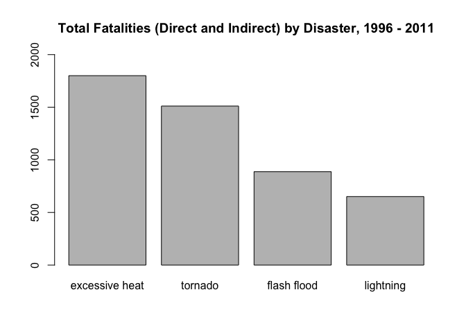

```r
with(fatalitiesByEvent, barplot(
  CUMULATIVEFATALITIES,
  names.arg = EVTYPE,
  ylim = c(0, 2000),
  main = "Total Fatalities (Direct and Indirect) by Disaster, 1996 - 2011",
  width = 1200
))
```

Figure 1: Cumulative fatalities for events with top-decile cumulative fatality values

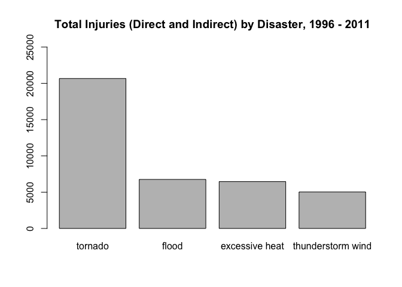

```r
with(injuriesByEvent, barplot(
  CUMULATIVEINJURIES,
  names.arg = EVTYPE,
  ylim = c(0, 25000),
  main = "Total Injuries (Direct and Indirect) by Disaster, 1996 - 2011",
  width = 1200
))
```

Figure 2: Cumulative injuries for events with top-decile cumulative injury values

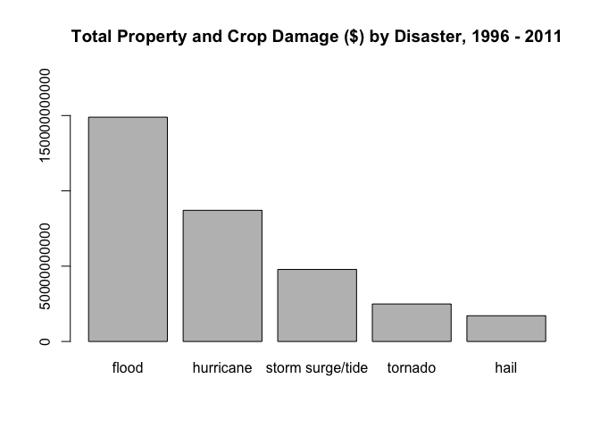

```r
with(damageByEvent, barplot(
  CUMULATIVEDMG,
  names.arg = EVTYPE,
  ylim = c(0, 180000000000),
  main = "Total Property and Crop Damage ($) by Disaster, 1996 - 2011",
  width = 1200
))
```

Figure 3: Cumulative damage for events with top-decile cumulative damage values

## Discussion

#### Accuracy of data not guaranteed

As described in the Storm Data documentation, some of the data was gathered from non-NWS sources, and its accuracy cannot be guaranteed. Therefore, the accuracy of these results cannot be guaranteed.

#### Issues grouping events together

Since the events were not properly labeled with event types, some decisions had to be made as to the re-labeling of event types. This may bias the results of the analysis. For instance, combined events (e.g. “flood/flash flood”), where each of the events is a separate Storm Data event, were discarded. “river flooding” was an event, and it was unclear whether or not this should fall under the “flood” event category in Storm Data, because “flood” is not a catch-all category in the Storm Data documentation (“flood”, “flash flood”, “lakeshore flood”, and “coastal flood”) were all separate categories. This might bias the results. Flood damage may have been underestimated, due to the separation into different categories.